# IFRS17

수익성에 관하여

sonsungman https://sonsungman.github.io/SKKU-Preditive.m/  
10-06-2021

### 서론

대학원 수업에서 바뀌는 보험회계 기준에 대한 특강을 수강하게 되었다. IASB가 제시한 보험계약에 대한 회계기준인 IFRS17의 경우 IFRS4에서 IFRS17으로 23년 전환하게 되고 비교 공시를 위해 22년 부터 실제로 보험사들은 공시를 해야한다. 이번 특강에서 국내 H대학에 재직 중이신 교수님께서 관련 논문에 관한 특강을 해주셨다. 논문의 요지는 수익과 비용에 있어 IFRS17의 원천이 다르기에 수익성 정보가 뒤틀리므로 이를 보완할 수 있는 부분이 필요하다는 것으로 이해했다. 교수님께서는 IFRS17이 굉장히 실무적인 부분에 있어 많은 논란과 이슈를 내포하고 있으며 이를 위해 많은 논의가 필요하다 주장하셨다. 이 글은 특강의 내용을 내 스스로 복기하며 소화한 것을 기록할 목적을 갖는다.

### 수익의 원천

IFRS4의 경우 수입보험료가 현금으로 들어보면 곧바로 보험 수익으로 인식되는 구조였다. 하지만 IFRS17의 경우 수익의 원천은 3가지로 분류된다. 먼저 상품 손익인 CSM(보험계약마진)의 상각이다. 두번째로 위험조정(RA)의 상각이다. 세번째로 예상보험금과 예상직접사업비를 수익으로 인식한다.

### 비용의 원천

IFRS4의 경우 실제보험금과 실제사업비가 또한 책임준비금 전입액이 비용의 원천이었다. 반면 IFRS17의 경우 실제보험금과 직접 사업비, 간접사업비(바로 비용 인식) 이 비용의 원천이 된다.

### 보험손익의 인식

IFRS17에서 보험이익의 경우 3가지 측면에서 발생한다. CSM 상각, RA상각, 예상과 실제치의 차이로 언급되는 경험조정. 이 3가지가 보험이익으로 인식되고 투자이익의 경우 따로 인식하게된다.

### IFRS17의 수익성 정보 문제점

교수님께서 논문에서 지적하신 문제점은 수익성 정보의 경우 CSM의 상각은 서비스(급부) 기반, 보험사건 발생확률 고려하지 않는반면 나머지 위험조정과 경험조정은 현금흐름 기반하여 보험사건 발생확률을 고려하기 때문에 수익 비용 대응과 이해가능성이 떨어진다는 것이다.

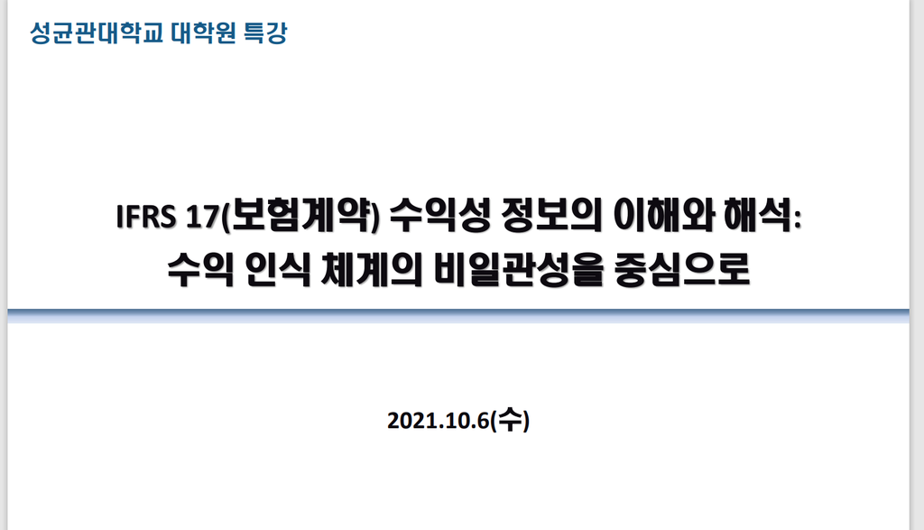

Figure 1: IFRS17 관련 자료